# 2.SparkSQLDataFrameOperations slides

## Dataframe operations

Spark DataFrames allow operations similar to pandas Dataframes. We demonstrate some of those.

For more, see the [official guide](https://spark.apache.org/docs/latest/sql-programming-guide.html) and [this article](https://www.analyticsvidhya.com/blog/2016/10/spark-dataframe-and-operations/)

```python
df.printSchema()
```

```
root
 |-- Station: string (nullable = true)
 |-- Measurement: string (nullable = true)
 |-- Year: integer (nullable = true)
 |-- Values: binary (nullable = true)
 |-- State: string (nullable = true)
```

```python
print(df.count())
df.show(1)
```

```
84199
+-----------+-----------+----+--------------------+-----+
|    Station|Measurement|Year|              Values|State|
+-----------+-----------+----+--------------------+-----+
|USC00303452|       PRCP|1903|[00 7E 00 7E 00 7...|   NY|
+-----------+-----------+----+--------------------+-----+
only showing top 1 row
```

### .describe()

The method `df.describe()` computes five statistics for each column of the dataframe `df`.

The statistics are: **count, mean, std, min,max**

```python
df.describe().select('station','measurement').show()
```

```
+-----------+-----------+
|    station|measurement|
+-----------+-----------+
|      84199|      84199|
|       null|       null|
|       null|       null|
|USC00300015|       PRCP|
|USW00094794|       TOBS|
+-----------+-----------+
```

#### groupby and agg

The method `.groupby(col)` groups rows according the value of the column `col`.  
The method `.agg(spec)` computes a summary for each group as specified in `spec`

```python
df.groupby('measurement').agg({'year': 'min', 'station':'count'}).show()
```

```
+-----------+---------+--------------+
|measurement|min(year)|count(station)|
+-----------+---------+--------------+
|       TMIN|     1873|         13442|
|       TOBS|     1876|         10956|
|       TMAX|     1873|         13437|
|       SNOW|     1884|         15629|
|       SNWD|     1888|         14617|
|       PRCP|     1871|         16118|
+-----------+---------+--------------+
```

### Using SQL queries on DataFrames

There are two main ways to manipulate DataFrames:

#### Imperative manipulation

Using python methods such as `.select` and `.groupby`.

- Advantage: order of operations is specified.
- Disrdavantage : You need to describe both **what** is the result you want and **how** to get it.

#### Declarative Manipulation (SQL)

- Advantage: You need to describe only **what** is the result you want.
- Disadvantage: SQL does not have primitives for common analysis operations such as **covariance**

#### Counting the number of occurances of each measurement, imparatively

```python
L=df.groupBy('measurement').count().collect()
#L is a list (collected DataFrame)
```

```python
D=[(e.measurement,e['count']) for e in L]
sorted(D,key=lambda x:x[1], reverse=False)[:6]
```

```
[('TOBS', 10956),
 ('TMAX', 13437),
 ('TMIN', 13442),
 ('SNWD', 14617),
 ('SNOW', 15629),
 ('PRCP', 16118)]
```

#### Counting the number of occurances of each measurement, declaratively.

```python
sqlContext.registerDataFrameAsTable(df,'weather') #using older sqlContext instead of newer (V2.0) sparkSession
```

```python
query="""
SELECT measurement,COUNT(measurement) AS count,
                   MIN(year) AS MinYear
FROM weather
GROUP BY measurement
ORDER BY count
"""
print(query)
sqlContext.sql(query).show()
```

```
SELECT measurement,COUNT(measurement) AS count,
                   MIN(year) AS MinYear
FROM weather
GROUP BY measurement
ORDER BY count

+-----------+-----+-------+
|measurement|count|MinYear|
+-----------+-----+-------+
|       TOBS|10956|   1876|
|       TMAX|13437|   1873|
|       TMIN|13442|   1873|
|       SNWD|14617|   1888|
|       SNOW|15629|   1884|
|       PRCP|16118|   1871|
+-----------+-----+-------+
```

#### Performing a map command

- In order to perform a `map` on a dataframe, you first need to transform it into an RDD.
- **Not** the recommended way. Better way is to use built-in sparkSQL functions.
- Or register new ones (Advanced).

```python
def find_century(row):
    if row.Year < 1900:
        return '19th'
    elif row.Year <2000:
        return '20th'
    elif row.Year <2010:
        return '21st'
    else:
        return 'possibly_bad_data'
```

```python
df.rdd.map(find_century).take(5)
```

```
['20th', '20th', '20th', '20th', '20th']
```

#### Aggregations

- **Aggregation** can be used, in combination with built-in sparkSQL functions to compute statistics of a dataframe.
- computation will be fast thanks to combined optimzations with database operations.
- A partial list : `count(), approx_count_distinct(), avg(), max(), min()`
- Of these, the interesting one is `approx_count_distinct()` which uses sampling to get an approximate count fast.

```python
df.agg({'station':'approx_count_distinct'}).show()
```

```
+------------------------------+
|approx_count_distinct(station)|
+------------------------------+
|                           339|
+------------------------------+
```

#### Approximate Quantile

- Suppose we want to partition the years into 10 ranges
- such that in each range we have approximately the same number of records.
- The method `.approxQuantile` will use a sample to do this for us.

```python
print('with accuracy 0.1: ',df.approxQuantile('year', [0.1*i for i in range(1,10)], 0.1))
print('with accuracy 0.01: ',df.approxQuantile('year', [0.1*i for i in range(1,10)], 0.01))
```

```
with accuracy 0.1:  [1871.0, 1945.0, 1949.0, 1965.0, 1972.0, 1978.0, 1984.0, 1988.0, 2013.0]
with accuracy 0.01:  [1917.0, 1936.0, 1949.0, 1957.0, 1966.0, 1975.0, 1984.0, 1993.0, 2003.0]
```

#### Lets collect the exact number of rows for each year

This will take much longer than ApproxQuantile on a large file

```python
# Lets collect the exact number of rows for each year ()
query='SELECT year,COUNT(year) AS count FROM weather GROUP BY year ORDER BY year'
print(query)
counts=sqlContext.sql(query)
print('counts is ',counts)
```

```
SELECT year,COUNT(year) AS count FROM weather GROUP BY year ORDER BY year
counts is  DataFrame[year: int, count: bigint]
```

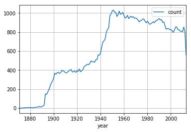

```python
import pandas as pd
A=counts.toPandas() # Transform a spark Dataframe to a Pandas Dataframe
A.plot.line('year','count')
grid()
```

### Reading rows selectively

Suppose we are only interested in snow measurements. We can apply an SQL query directly to the parquet files. As the data is organized in columnar structure, we can do the selection efficiently without loading the whole file to memory.

Here the file is small, but in real applications it can consist of hundreds of millions of records. In such cases loading the data first to memory and then filtering it is very wasteful.

```python
data_dir='../../Data'
query="""SELECT station,measurement,year
FROM parquet.`%s.parquet`
WHERE measurement=\"SNOW\" """%(weather_dir+'/'+zip_file[:-4])
print(query)
df2 = sqlContext.sql(query)
print(df2.count(),df2.columns)
df2.show(5)
```

```
SELECT station,measurement,year
FROM parquet.`/home/jovyan/work/Sections/Data/Weather/NY.parquet`
WHERE measurement="SNOW"
15629 ['station', 'measurement', 'year']
+-----------+-----------+----+
|    station|measurement|year|
+-----------+-----------+----+
|USC00303452|       SNOW|1903|
|USC00303452|       SNOW|1904|
|USC00303452|       SNOW|1905|
|USC00303452|       SNOW|1906|
|USC00303452|       SNOW|1907|
+-----------+-----------+----+
only showing top 5 rows
```

## Summary

- Dataframes can be manipulated decleratively, which allows for more optimization.
- Dataframes can be stored and retrieved from Parquet files.
- It is possible to refer directly to a parquet file in an SQL query.
- See you next time!